# R Notebook

```r
##install.packages("gapminder")
# Load the gapminder package
library(gapminder)

# Load the dplyr package
library(dplyr)

# Look at the gapminder dataset
gapminder <- as.tibble(gapminder)

gapminder
```

[output not shown]

# Introduction to the Tidyverse

## Data Wrangling

### Filter

```r
gapminder %>%
  filter(year == 2007)

gapminder %>%
  filter(country == "United States")


gapminder %>%
  filter(year == 2007, country == "United States")
```

[output not shown]

```r
gapminder %>%
  filter(year == 1957)

gapminder %>%
  filter(country == "China", year == 2002)
```

[output not shown]

### Arrange

```r
gapminder %>%
  arrange(gdpPercap)

gapminder %>%
  arrange(desc(gdpPercap))


gapminder %>%
  filter(year ==2007) %>%
  arrange(desc(gdpPercap))
```

[output not shown]

```r
# Sort in ascending order of lifeExp
gapminder %>%
  arrange(lifeExp)



# Sort in descending order of lifeExp
gapminder %>%
  arrange(desc(lifeExp))

# Filter for the year 1957, then arrange in descending order of population
gapminder %>%
  filter(year == 1957) %>%
  arrange(desc(pop))
```

[output not shown]

### Mutate

```r
gapminder %>%
  mutate(pop = pop/1000000)

gapminder %>%
  mutate(gdp = gdpPercap * pop)

gapminder %>%
  mutate(gdp = gdpPercap * pop) %>%
  filter(year == 2007) %>%
  arrange(desc(gdp))
```

[output not shown]

```r
# Use mutate to change lifeExp to be in months
gapminder %>%
  mutate(lifeExp = lifeExp * 12)

# Use mutate to create a new column called lifeExpMonths
gapminder %>%
  mutate(lifeExpMonths = lifeExp * 12)


gapminder %>%
  filter(year == 2007) %>%
  mutate(lifeExpMonths = lifeExp * 12) %>%
  arrange(desc(lifeExpMonths))
```

[output not shown]

## Data Visualization

### Visualizing with ggplot2

```r
library(ggplot2)
gapminder2007 <- gapminder %>%
  filter(year == 2007)

gapminder2007

ggplot(gapminder2007, aes(x = gdpPercap, y = lifeExp)) +
  geom_point()
```

[output not shown]

#### Variable Assignment

Variable assignment Throughout the exercises in this chapter, you’ll be visualizing a subset of the gapminder data from the year 1952. First, you’ll have to load the ggplot2 package, and create a gapminder_1952 dataset to visualize.

INSTRUCTIONS 100 XP Load the ggplot2 package after the gapminder and dplyr packages. Filter gapminder for observations from the year 1952, and assign it to a new dataset gapminder_1952 using the assignment operator (<-).

```r
# Load the ggplot2 package as well
library(gapminder)
library(dplyr)
library(ggplot2)


# Create gapminder_1952
gapminder_1952 <- gapminder %>%
  filter(year == 1952)
```

#### Comparing population and GDP per capita

Comparing population and GDP per capita In the video you learned to create a scatter plot with GDP per capita on the x-axis and life expectancy on the y-axis (the code for that graph is shown here). When you’re exploring data visually, you’ll often need to try different combinations of variables and aesthetics.

INSTRUCTIONS 100 XP Change the scatter plot of gapminder_1952 so that (pop) is on the x-axis and GDP per capita (gdpPercap) is on the y-axis.

```r
library(gapminder)
library(dplyr)
library(ggplot2)

gapminder_1952 <- gapminder %>%
  filter(year == 1952)

# Change to put pop on the x-axis and gdpPercap on the y-axis
ggplot(gapminder_1952, aes(x = pop, y = gdpPercap)) +
  geom_point()
```

[output not shown]

#### Comparing population and life expectancy

Comparing population and life expectancy In this exercise, you’ll use ggplot2 to create a scatter plot from scratch, to compare each country’s population with its life expectancy in the year 1952.

INSTRUCTIONS 100 XP Create a scatter plot of gapminder_1952 with population (pop) is on the x-axis and life expectancy (lifeExp) on the y-axis.

```r
ibrary(gapminder)
library(dplyr)
library(ggplot2)

gapminder_1952 <- gapminder %>%
  filter(year == 1952)

# Create a scatter plot with pop on the x-axis and lifeExp on the y-axis
ggplot(gapminder_1952,
       aes(x = pop,
           y = lifeExp)) +
  geom_point()
```

[output not shown]

### Log Scales

```r
library(gapminder)
library(dplyr)
library(ggplot2)

gapminder_2007 <- gapminder %>%
  filter(year == 2007)


ggplot(gapminder_2007,
       aes(x = gdpPercap,
           y = lifeExp)) +
  geom_point() +
  scale_x_log10()
```

[output not shown]

#### Putting the x-axis on a log scale

Putting the x-axis on a log scale You previously created a scatter plot with population on the x-axis and life expectancy on the y-axis. Since population is spread over several orders of magnitude, with some countries having a much higher population than others, it’s a good idea to put the x-axis on a log scale.

INSTRUCTIONS 100 XP Change the existing scatter plot (code provided) to put the x-axis (representing population) on a log scale.

```r
library(gapminder)
library(dplyr)
library(ggplot2)

gapminder_1952 <- gapminder %>%
  filter(year == 1952)

# Change this plot to put the x-axis on a log scale
ggplot(gapminder_1952, aes(x = pop, y = lifeExp)) +
  geom_point() +
  scale_x_log10()
```

[output not shown]

#### Putting the x- and y- axes on a log scale

Putting the x- and y- axes on a log scale Suppose you want to create a scatter plot with population on the x-axis and GDP per capita on the y-axis. Both population and GDP per-capita are better represented with log scales, since they vary over many orders of magnitude.

INSTRUCTIONS 100 XP Create a scatter plot with population (pop) on the x-axis and GDP per capita (gdpPercap) on the y-axis. Put both the x- and y- axes on a log scale.

```r
library(gapminder)
library(dplyr)
library(ggplot2)

gapminder_1952 <- gapminder %>%
  filter(year == 1952)

# Scatter plot comparing pop and gdpPercap, with both axes on a log scale
ggplot(gapminder_1952,
       aes(x = pop,
           y = gdpPercap)) +
  geom_point() +
  scale_x_log10() +
  scale_y_log10()
```

[output not shown]

### Additional aesthetics

Now adding color and size aesthetics Color

```r
ggplot(gapminder_2007,
       aes(x = gdpPercap,
           y = lifeExp,
           color = continent)) +
  geom_point() +
  scale_x_log10()
```

[output not shown]

Size

```r
ggplot(gapminder_2007,
       aes(x = gdpPercap,
           y = lifeExp,
           color = continent,
           size = pop)) +
  geom_point() +
  scale_x_log10()
```

[output not shown]

#### Adding color to a scatterplot

Adding color to a scatter plot In this lesson you learned how to use the color aesthetic, which can be used to show which continent each point in a scatter plot represents.

INSTRUCTIONS 100 XP Create a scatter plot with population (pop) on the x-axis, life expectancy (lifeExp) on the y-axis, and with continent (continent) represented by the color of the points. Put the x-axis on a log scale.

```r
library(gapminder)
library(dplyr)
library(ggplot2)

gapminder_1952 <- gapminder %>%
  filter(year == 1952)

# Scatter plot comparing pop and lifeExp, with color representing continent
ggplot(gapminder_1952,
       aes(x = pop,
           y = lifeExp,
           color = continent)) +
  geom_point() +
  scale_x_log10()
```

[output not shown]

#### Adding size and color to a plot

Adding size and color to a plot In the last exercise, you created a scatter plot communicating information about each country’s population, life expectancy, and continent. Now you’ll use the size of the points to communicate even more.

INSTRUCTIONS 100 XP Modify the scatter plot so that the size of the points represents each country’s GDP per capita (gdpPercap).

```r
library(gapminder)
library(dplyr)
library(ggplot2)

gapminder_1952 <- gapminder %>%
  filter(year == 1952)

# Add the size aesthetic to represent a country's gdpPercap
ggplot(gapminder_1952,
       aes(x = pop,
           y = lifeExp,
           color = continent,
           size = gdpPercap)) +
  geom_point() +
  scale_x_log10()
```

[output not shown]

### Faceting

Using subplots to visualize the data and its relationships

```r
ggplot(gapminder_2007,
       aes(x = gdpPercap,
           y = lifeExp)) +
  geom_point() +
  scale_x_log10() +
  facet_wrap(~ continent) ##that is a tilde - which in R typically means "by"
```

[output not shown]

#### Creating a subgraph for each continent

Creating a subgraph for each continent You’ve learned to use faceting to divide a graph into subplots based on one of its variables, such as the continent.

INSTRUCTIONS 100 XP Create a scatter plot of gapminder_1952 with the x-axis representing population (pop), the y-axis representing life expectancy (lifeExp), and faceted to have one subplot per continent (continent). Put the x-axis on a log scale.

```r
library(gapminder)
library(dplyr)
library(ggplot2)

gapminder_1952 <- gapminder %>%
  filter(year == 1952)

# Scatter plot comparing pop and lifeExp, faceted by continent
ggplot(gapminder_1952,
       aes(x = pop,
           y = lifeExp)) +
  geom_point() +
  scale_x_log10() +
  facet_wrap(~continent)
```

[output not shown]

#### Faceting by year

Faceting by year All of the graphs in this chapter have been visualizing statistics within one year. Now that you’re able to use faceting, however, you can create a graph showing all the country-level data from 1952 to 2007, to understand how global statistics have changed over time.

INSTRUCTIONS 100 XP Create a scatter plot of the gapminder data: Put GDP per capita (gdpPercap) on the x-axis and life expectancy (lifeExp) on the y-axis, with continent (continent) represented by color and population (pop) represented by size. Put the x-axis on a log scale Facet by the year variable

```r
library(gapminder)
library(dplyr)
library(ggplot2)

# Scatter plot comparing gdpPercap and lifeExp, with color representing continent
# and size representing population, faceted by year
ggplot(gapminder,
       aes(x = gdpPercap,
           y = lifeExp,
           color = continent,
           size = pop)) +
  geom_point() +
  scale_x_log10() +
  facet_wrap(~year)
```

[output not shown]

## Grouping and Summarizing

### The summarize verb

Turns many rows into one row

Summarize functions: *mean* sum *median* min *max

```r
library(gapminder)
##returns mean life expectancy across all data
gapminder %>%
  summarize(meanLifeExp = mean(lifeExp))

##returns mean life expectancy from 2007 data
gapminder %>%
  filter(year == 2007) %>%
  summarize(meanLifeExp = mean(lifeExp))

##returns mean life expectancy and total population from 2007 data
gapminder %>%
  filter(year == 2007) %>%
  summarize(meanLifeExp = mean(lifeExp),
            totalPop = sum(as.numeric(pop))
  )
```

[output not shown]

#### Summarizing the median life expectancy

You’ve seen how to find the mean life expectancy and the total population across a set of observations, but mean() and sum() are only two of the functions R provides for summarizing a collection of numbers. Here, you’ll learn to use the median() function in combination with summarize().

By the way, dplyr displays some messages when it’s loaded that we’ve been hiding so far. They’ll show up in red and start with:

Attaching package: ‘dplyr’

The following objects are masked from ‘package:stats’: This will occur in future exercises each time you load dplyr: it’s mentioning some built-in functions that are overwritten by dplyr. You won’t need to worry about this message within this course.

INSTRUCTIONS 100 XP Use the median() function within a summarize() to find the median life expectancy. Save it into a column called medianLifeExp.

| medianLifeExp |
| --- |
| 60.7125 |

#### Summarizing the median life expectancy in 1957

Rather than summarizing the entire dataset, you may want to find the median life expectancy for only one particular year. In this case, you’ll find the median in the year 1957.

INSTRUCTIONS 100 XP Filter for the year 1957, then use the median() function within a summarize() to calculate the median life expectancy into a column called medianLifeExp.

| medianLifeExp |
| --- |
| 48.3605 |

#### Summarizing multiple variables in 1957

The summarize() verb allows you to summarize multiple variables at once. In this case, you’ll use the median() function to find the median life expectancy and the max() function to find the maximum GDP per capita.

INSTRUCTIONS 100 XP Find both the median life expectancy (lifeExp) and the maximum GDP per capita (gdpPercap) in the year 1957, calling them medianLifeExp and maxGdpPercap respectively. You can use the max() function to find the maximum.

| medianLifeExp | maxGdpPerCap |
| --- | --- |
| 48.3605 | 113523.1 |

### The group_by verb

Like summarize - but summarizes in groups instead of the entire dataset

| year | continent | meanLifeExp | totalPop |
| --- | --- | --- | --- |
| 1952 | Africa | 39.13550 | 237640501 |
| 1952 | Americas | 53.27984 | 345152446 |
| 1952 | Asia | 46.31439 | 1395357351 |
| 1952 | Europe | 64.40850 | 418120846 |
| 1952 | Oceania | 69.25500 | 10686006 |
| 1957 | Africa | 41.26635 | 264837738 |
| 1957 | Americas | 55.96028 | 386953916 |
| 1957 | Asia | 49.31854 | 1562780599 |
| 1957 | Europe | 66.70307 | 437890351 |
| 1957 | Oceania | 70.29500 | 11941976 |

[output cut: 50 more lines]

#### Summarizing by year

In a previous exercise, you found the median life expectancy and the maximum GDP per capita in the year 1957. Now, you’ll perform those two summaries within each year in the dataset, using the group_by verb.

INSTRUCTIONS 100 XP Find the median life expectancy (lifeExp) and maximum GDP per capita (gdpPercap) within each year, saving them into medianLifeExp and maxGdpPercap, respectively.

| year | medianLifeExp | maxGdpPercap |
| --- | --- | --- |
| 1952 | 45.1355 | 108382.35 |
| 1957 | 48.3605 | 113523.13 |
| 1962 | 50.8810 | 95458.11 |
| 1967 | 53.8250 | 80894.88 |
| 1972 | 56.5300 | 109347.87 |
| 1977 | 59.6720 | 59265.48 |
| 1982 | 62.4415 | 33693.18 |
| 1987 | 65.8340 | 31540.97 |
| 1992 | 67.7030 | 34932.92 |
| 1997 | 69.3940 | 41283.16 |

[output cut: 2 more lines]

#### Summarizing by continent

| continent | medianLifeExp | maxGdpPercap |
| --- | --- | --- |
| Africa | 52.9265 | 13206.48 |
| Americas | 72.8990 | 42951.65 |
| Asia | 72.3960 | 47306.99 |
| Europe | 78.6085 | 49357.19 |
| Oceania | 80.7195 | 34435.37 |

#### Summarizing by continent and year

Instead of grouping just by year, or just by continent, you’ll now group by both continent and year to summarize within each.

INSTRUCTIONS 100 XP Find the median life expectancy (lifeExp) and maximum GDP per capita (gdpPercap) within each combination of continent and year, saving them into medianLifeExp and maxGdpPercap, respectively.

| continent | year | medianLifeExp | maxGdpPercap |
| --- | --- | --- | --- |
| Africa | 1952 | 38.8330 | 4725.296 |
| Africa | 1957 | 40.5925 | 5487.104 |
| Africa | 1962 | 42.6305 | 6757.031 |
| Africa | 1967 | 44.6985 | 18772.752 |
| Africa | 1972 | 47.0315 | 21011.497 |
| Africa | 1977 | 49.2725 | 21951.212 |
| Africa | 1982 | 50.7560 | 17364.275 |
| Africa | 1987 | 51.6395 | 11864.408 |
| Africa | 1992 | 52.4290 | 13522.158 |
| Africa | 1997 | 52.7590 | 14722.842 |

[output cut: 50 more lines]

### Visualizing summarized data

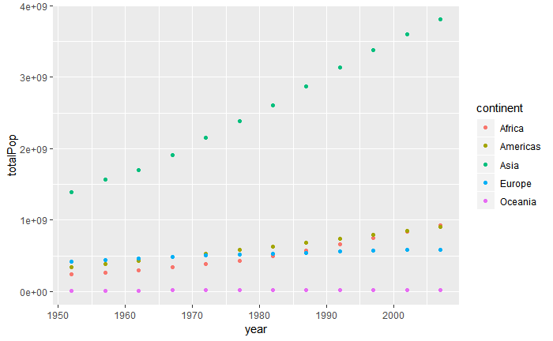

#### Visualizing median life expectancy over time

In the last chapter, you summarized the gapminder data to calculate the median life expectancy within each year. This code is provided for you, and is saved (with <-) as the by_year dataset.

Now you can use the ggplot2 package to turn this into a visualization of changing life expectancy over time.

INSTRUCTIONS 100 XP Use the by_year dataset to create a scatter plot showing the change of median life expectancy over time, with year on the x-axis and medianLifeExp on the y-axis. Be sure to add expand_limits(y = 0) to make sure the plot’s y-axis includes zero.

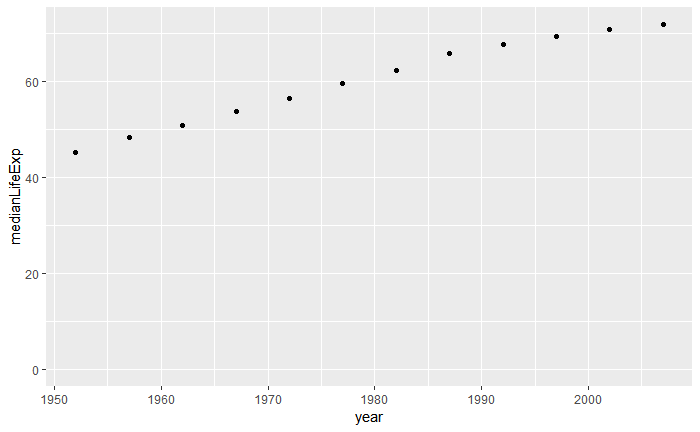

#### Visualizing median GDP per capita per continent over time

In the last exercise you were able to see how the median life expectancy of countries changed over time. Now you’ll examine the median GDP per capita instead, and see how the trend differs among continents.

INSTRUCTIONS 100 XP Summarize the gapminder dataset by continent and year, finding the median GDP per capita (gdpPercap) within each and putting it into a column called medianGdpPercap. Use the assignment operator <- to save this summarized data as by_year_continent. Create a scatter plot showing the change in medianGdpPercap by continent over time. Use color to distinguish between continents, and be sure to add expand_limits(y = 0) so that the y-axis starts at zero.

[figure not shown]

#### Comparing median life expectancy and median GDP per continent in 2007

In these exercises you’ve generally created plots that show change over time. But as another way of exploring your data visually, you can also use ggplot2 to plot summarized data to compare continents within a single year.

INSTRUCTIONS 100 XP Filter the gapminder dataset for the year 2007, then summarize the median GDP per capita and the median life expectancy within each continent, into columns called medianLifeExp and medianGdpPercap. Save this as by_continent_2007. Use the by_continent_2007 data to create a scatterplot comparing these summary statistics for continents in 2007, putting the median GDP per capita on the x-axis to the median life expectancy on the y-axis. Color the scatter plot by continent. You don’t need to add expand_limits(y = 0) for this plot.

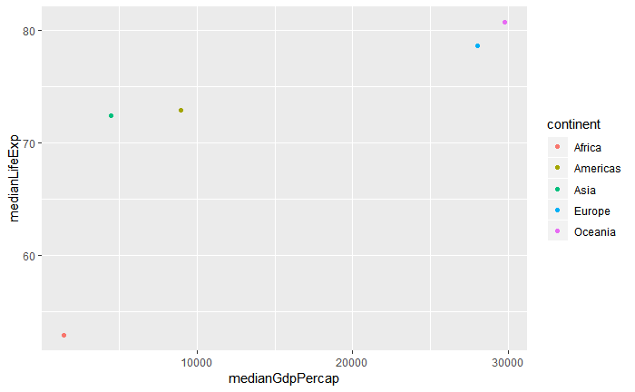